# Multiple Regression: Diagnostics - Week 10, Lecture 1

Author

Hector Gavilanes

**Recall the airline data from last week; we modeled revenue as a function of distance and population. The data are given here: [Google Sheet](https://docs.google.com/spreadsheets/d/10ZN0jMYdVsG2ucIJFSTquVRW916Jj-JmZIGQuqSQhy0/edit?usp=sharing).**

## Libraries

```r
library(tidyverse)
library(gsheet)
library(lindia) # Influence & Leverage: gg_cooksd()
library(car) #multicollinearity: vif()
library(olsrr) #multicollinearity: vif()
library(ggpubr) #side-by-side graphs
library(formattable)
```

## Data

```r
# clear environment
rm(list = ls())

# extract data
data <- as_tibble(gsheet2tbl("https://docs.google.com/spreadsheets/d/10ZN0jMYdVsG2ucIJFSTquVRW916Jj-JmZIGQuqSQhy0/edit?usp=sharing"))
```

1. Summarize your findings from last week. What was the resulting model, which were significant predictors of revenue (no formal hypothesis test needed - just state with appropriate evidence)? Also include the graph constructed to visualize the model.

#### Summary

```r
# Summary
data %>%
  select(Revenue, Distance, Population) %>%
  summary(data)
```

```
    Revenue         Distance       Population
 Min.   :200.0   Min.   :125.0   Min.   : 52.00
 1st Qu.:236.2   1st Qu.:170.0   1st Qu.: 61.00
 Median :253.0   Median :211.0   Median : 73.50
 Mean   :269.2   Mean   :206.4   Mean   : 82.18
 3rd Qu.:275.0   3rd Qu.:232.8   3rd Qu.: 94.00
 Max.   :450.0   Max.   :340.0   Max.   :240.00
```

#### Correlation

```r
# calculate Pearson's correlation matrix
cor(data,
    method = "pearson",
    use = "complete.obs")
```

```
             Airport     Revenue    Distance Population
Airport    1.0000000  0.16143216  0.25688600  0.2407534
Revenue    0.1614322  1.00000000 -0.02706024  0.7622405
Distance   0.2568860 -0.02706024  1.00000000 -0.2396499
Population 0.2407534  0.76224046 -0.23964989  1.0000000
```

There is a correlation between Revenue and Population which is 0.762.

```r
airport_model <- lm(data$Revenue ~ data$Population + data$Distance)
summary(airport_model)
```

```
Call:
lm(formula = data$Revenue ~ data$Population + data$Distance)

Residuals:
   Min     1Q Median     3Q    Max
-83.98 -14.99  -2.84  13.49  69.95

Coefficients:
                Estimate Std. Error t value Pr(>|t|)
(Intercept)     144.3885    39.5312   3.653  0.00169 **
data$Population   1.0942     0.2022   5.411  3.2e-05 ***
data$Distance     0.1692     0.1519   1.114  0.27916
---
Signif. codes:  0 '***' 0.001 '**' 0.01 '*' 0.05 '.' 0.1 ' ' 1

Residual standard error: 34.7 on 19 degrees of freedom
Multiple R-squared:  0.6067,    Adjusted R-squared:  0.5653
F-statistic: 14.65 on 2 and 19 DF,  p-value: 0.0001412
```

## Model formula:

$$\hat{y} = 144.39 + 1.09{\text{ population}} + 0.17{\text{ distance}}$$

- Population is a significant predictor with $p < 0.001$.
- Distance is not a significant predictor with $p = 0.279$.
- The regression model is significant with $p < 0.001$

#### Graph the Multiple Linear Model

#### Visualizing Population

```r
# get coefficients
c1 <- coefficients(airport_model)
c1
```

```
    (Intercept) data$Population   data$Distance
    144.3884744       1.0942418       0.1691772
```

```r
# Population on the X-axis
quantile(data$Distance, na.rm = TRUE)
```

```
    0%    25%    50%    75%   100%
125.00 170.00 211.00 232.75 340.00
```

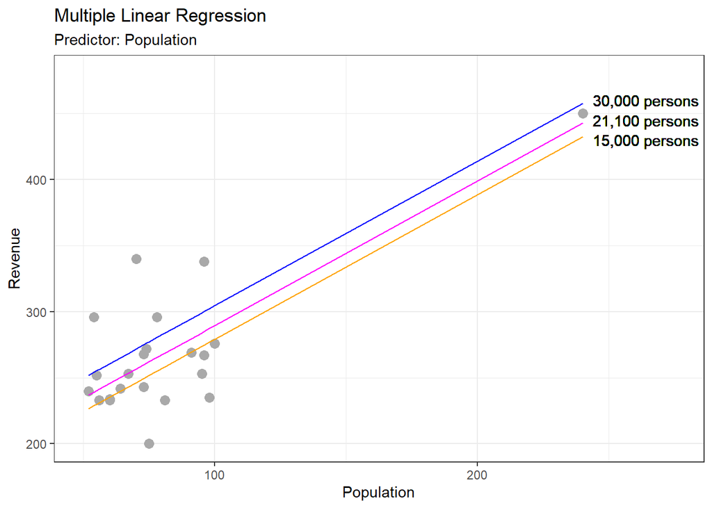

```r
# create lines graph for Population of 150, 211, 300
data <- data %>%
  mutate(p150 = c1[1] + c1[2]*Population + c1[3]*150,
         p211 = c1[1] + c1[2]*Population + c1[3]*211,
         p300 = c1[1] + c1[2]*Population + c1[3]*300)

# Population ggplot
gg_population <- data %>% ggplot(aes(x = Population, y = Revenue)) +
  geom_point(size=3, color = "darkgray") +
  geom_line(aes(y = p150), color = "orange") +
  geom_line(aes(y = p211), color = "magenta") +
  geom_line(aes(y = p300), color = "blue") +
  geom_text(aes(x =264, y = 460, label = "30,000 persons")) +
  geom_text(aes(x = 264, y = 445, label = "21,100 persons")) +
  geom_text(aes(x = 264, y = 430, label = "15,000 persons")) +
  labs(title = "Multiple Linear Regression",
       subtitle = "Predictor: Population",
       x = "Population",
       y = "Revenue") +
  xlim(c(50, 275))+
  ylim(c(200, 480))+
  theme_bw()
gg_population
```

#### Visualizing Distance

```r
# Distance on the X-axis
quantile(data$Population, na.rm = TRUE)
```

```
   0%   25%   50%   75%  100%
 52.0  61.0  73.5  94.0 240.0
```

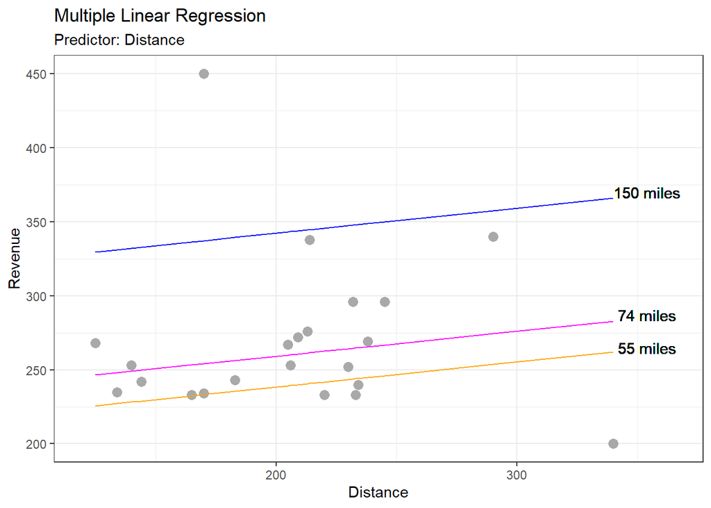

```r
# create lines graph for Distance of 55, 74, 150
data <- data %>%
  mutate(d55 = c1[1] + c1[2]*55 + c1[3]*Distance,
         d74 = c1[1] + c1[2]*74 + c1[3]*Distance,
         d150 = c1[1] + c1[2]*150 + c1[3]*Distance)

# Distance ggplot
gg_distance <- data %>% ggplot(aes(x = Distance, y = Revenue)) +
  geom_point(size=3, color = "darkgray") +
  geom_line(aes(y = d55), color = "orange") +
  geom_line(aes(y = d74), color = "magenta") +
  geom_line(aes(y = d150), color = "blue") +
  geom_text(aes(x = 354, y = 370, label = "150 miles")) +
  geom_text(aes(x = 354, y = 287, label = "74 miles")) +
  geom_text(aes(x = 354, y = 265, label = "55 miles")) +
  labs(title = "Multiple Linear Regression",
       subtitle = "Predictor: Distance",
       x = "Distance",
       y = "Revenue") +
  xlim(c(120, 365))+
  ylim(c(200, 450))+
  theme_bw()
gg_distance
```

2. Determine if there are outliers in this model. Be sure to count and list the observations that are outliers.

```r
n = 2.5
data <- data %>%
  mutate(Outlier = abs(rstandard(airport_model)) > n)
data %>% count(Outlier)
```

```
# A tibble: 2 × 2
  Outlier     n
  <lgl>   <int>
1 FALSE      21
2 TRUE        1
```

```r
outlier_df <- data %>%
  select(Revenue, Distance, Population, Outlier) %>%
  drop_na() %>%
  mutate(obs = row_number())
formattable(outlier_df) %>%
  filter(Outlier == TRUE)
```

| Revenue | Distance | Population | Outlier | obs |
| --- | --- | --- | --- | --- |
| 200 | 340 | 75 | TRUE | 22 |

- From our test, observation 22 is an outlier.
3. Determine if there are any influence and leverage points in this model. Be sure to count and list the observations that are considered influential and leverage.

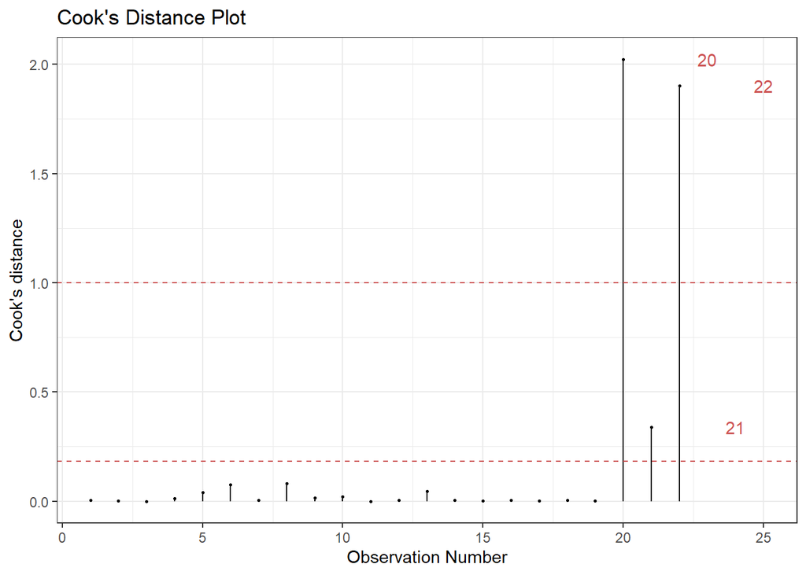

```r
gg_cooksd(airport_model) + theme_bw()
```

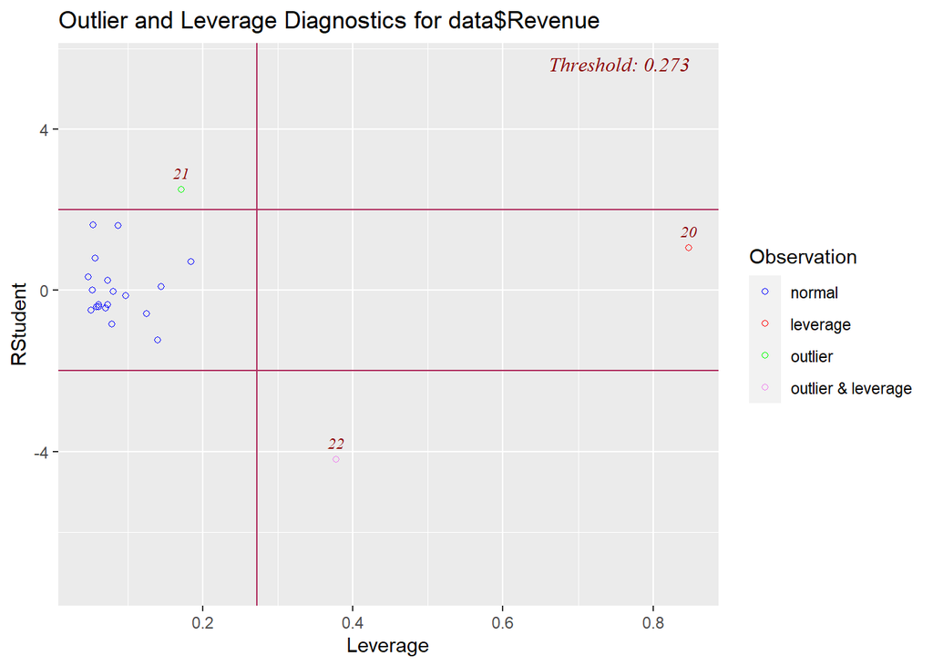

```r
ols_plot_resid_lev(airport_model)
```

- Points 20, 21, 22 need further investigation.
4. Is there evidence of multicollinearity?

```r
# vif(airport_model)
ols_vif_tol(airport_model)
```

```
        Variables Tolerance      VIF
1 data$Population 0.9425679 1.060931
2   data$Distance 0.9425679 1.060931
```

- No multicollinearity is present.
5. Perform a sensitivity analysis: remove the data points identified as potential offenders in Q2 and Q3 and reconstruct the model. Be sure to state the resulting model.

```r
sensitivity_df <- outlier_df %>%
  filter(Outlier == FALSE & !obs %in% c(20, 21, 22))
# data$Revenue ~ data$Population + data$Distance
sensitivity_model <- lm(sensitivity_df$Revenue ~ sensitivity_df$Population + sensitivity_df$Distance)
summary(sensitivity_model)
```

```
Call:
lm(formula = sensitivity_df$Revenue ~ sensitivity_df$Population +
    sensitivity_df$Distance)

Residuals:
    Min      1Q  Median      3Q     Max
-23.590 -15.981  -3.924   9.350  54.893

Coefficients:
                          Estimate Std. Error t value Pr(>|t|)
(Intercept)               128.8925    45.5454   2.830   0.0121 *
sensitivity_df$Population   0.8287     0.3505   2.364   0.0310 *
sensitivity_df$Distance     0.3489     0.1511   2.308   0.0347 *
---
Signif. codes:  0 '***' 0.001 '**' 0.01 '*' 0.05 '.' 0.1 ' ' 1

Residual standard error: 23.9 on 16 degrees of freedom
Multiple R-squared:  0.3441,    Adjusted R-squared:  0.2621
F-statistic: 4.197 on 2 and 16 DF,  p-value: 0.03426
```

## Sensitivity Model formula:

$$\hat{y} = 128.89 + 0.83{\text{ population}} + 0.35{\text{ distance}}$$

6. Using the model in Q5, are there any significant predictors of revenue?
- Population is a significant predictor with $p = 0.0310$.
- Distance is a significant predictor with $p = 0.0347$.
- The regression model is significant with $p = 0.0343$
7. Reconstruct the data visualization from last week, but using the new model’s results. #### Graph the Sensitivity Multiple Linear Model

#### Visualizing Distance

```r
# get coefficients
c1 <- coefficients(sensitivity_model)

# Distance on the X-axis
quantile(sensitivity_df$Population, na.rm = TRUE)
```

```
  0%  25%  50%  75% 100%
  52   60   73   93  100
```

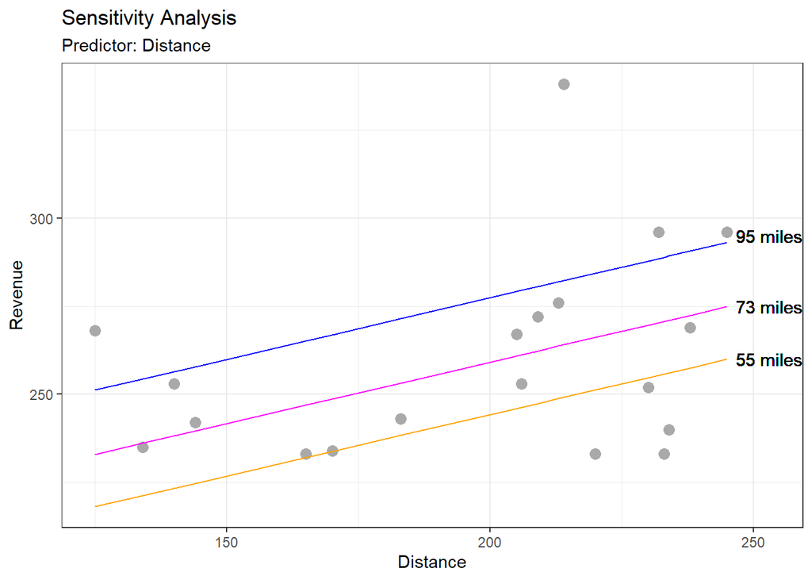

```r
# create lines graph for Distance of 55, 73, 95
sensitivity_df <- sensitivity_df %>%
  mutate(d55 = c1[1] + c1[2]*55 + c1[3]*Distance,
         d73 = c1[1] + c1[2]*73 + c1[3]*Distance,
         d95 = c1[1] + c1[2]*95 + c1[3]*Distance)

# Distance sensitivity ggplot
gg_sensitivity_distance <- sensitivity_df %>% ggplot(aes(x = Distance, y = Revenue)) +
  geom_point(size=3, color = "darkgray") +
  geom_line(aes(y = d55), color = "orange") +
  geom_line(aes(y = d73), color = "magenta") +
  geom_line(aes(y = d95), color = "blue") +
  geom_text(aes(x = 253, y = 295, label = "95 miles")) +
  geom_text(aes(x = 253, y = 275, label = "73 miles")) +
  geom_text(aes(x = 253, y = 260, label = "55 miles")) +
  labs(title = "Sensitivity Analysis",
       subtitle = "Predictor: Distance",
       x = "Distance",
       y = "Revenue") +
  theme_bw()

gg_sensitivity_distance
```

```r
distance_comparison <- gg_sensitivity_distance +
  xlim(c(120, 365))+
  ylim(c(200, 450))
```

#### Visualizing Population

```r
# Population on the X-axis
quantile(sensitivity_df$Distance, na.rm = TRUE)
```

```
   0%   25%   50%   75%  100%
125.0 167.5 209.0 231.0 245.0
```

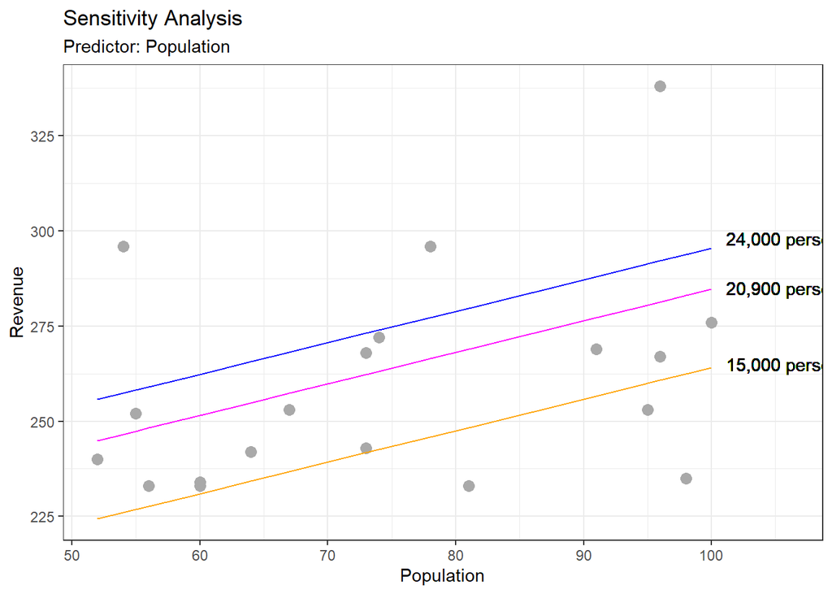

```r
# create lines graph for Population of 150, 209, 240
sensitivity_df <- sensitivity_df %>%
  mutate(p150 = c1[1] + c1[2]*Population + c1[3]*150,
         p209 = c1[1] + c1[2]*Population + c1[3]*209,
         p240 = c1[1] + c1[2]*Population + c1[3]*240)

# Sensitivity Population ggplot
gg_sensitivity_population <- sensitivity_df %>% ggplot(aes(x = Population, y = Revenue)) +
  geom_point(size=3, color = "darkgray") +
  geom_line(aes(y = p150), color = "orange") +
  geom_line(aes(y = p209), color = "magenta") +
  geom_line(aes(y = p240), color = "blue") +
  geom_text(aes(x =106, y = 298, label = "24,000 persons")) +
  geom_text(aes(x = 106, y = 285, label = "20,900 persons")) +
  geom_text(aes(x = 106, y = 265, label = "15,000 persons")) +
  labs(title = "Sensitivity Analysis",
       subtitle = "Predictor: Population",
       x = "Population",
       y = "Revenue") +
  theme_bw()

gg_sensitivity_population
```

```r
population_comparison <- gg_sensitivity_population +
  xlim(c(50, 275))+
  ylim(c(200, 480))
```

8. Put the graphs from last week and Q7 side by side (hint: use `ggpubr`).

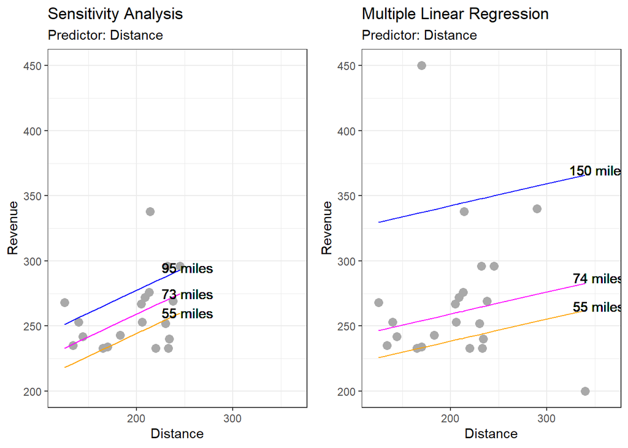

```r
ggarrange(distance_comparison, gg_distance, ncol = 2, nrow = 1)
```

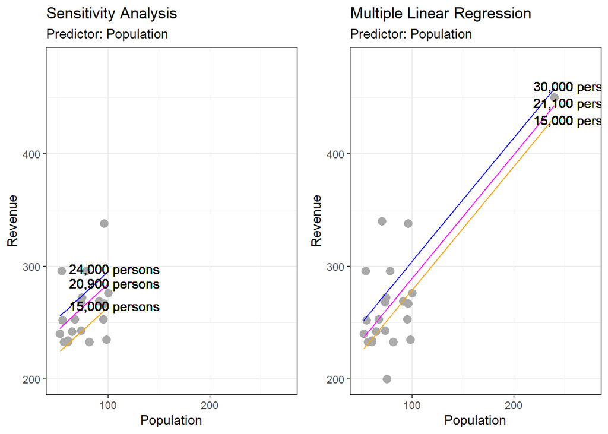

```r
ggarrange(population_comparison, gg_population, ncol = 2, nrow = 1)
```

9. Compare and contrast the modeling results and the graphs that are side by side in Q8.

## Sensitivity Analysis

$$\hat{y} = 144.39 + 1.09{\text{ population}} + 0.17{\text{ distance}}$$

- Population is a significant predictor with $p < 0.001$.
- Distance is not a significant predictor with $p = 0.279$.
- The regression model is significant with $p < 0.001$

$$\hat{y} = 128.89 + 0.83{\text{ population}} + 0.35{\text{ distance}}$$

- Population is a significant predictor with $p = 0.0310$.
- Distance is a significant predictor with $p = 0.0347$.
- The regression model is significant with $p = 0.0343$
10. Why do you think I assigned this particular dataset for analysis? What are you taking away from this assignment?

In this particular assignment, the data has outliers with high influence and high leverage. After removing three outliers, our model is different from the original one. Further investigation is needed to determine possible data collection problems.

Some true outliers represent natural variations, and they should be left intact in the dataset. Other outliers are problematic, and should be removed because they represent measurement errors, data entry or processing errors, or poor sampling. All statistical models depends on excellent data collection to produce reliable results.